# Missing Data practical Week 4

Kim Luijken, adapted from work by Valentijn de Jong and Thomas Debray

2022

This practical was developed using R version 4.1.1.

## Introduction

You perform a cohort study on annual influenza vaccine effectiveness. The aim of the study is to assess whether annual influenza vaccination reduces the risk of hospitalisation. The data consist of observations on eligible subjects who did, or did not, receive the annual influenza vaccine. The endpoint in this study is hospitalisation during the influenza epidemic period. Note that the vaccine was not randomly allocated; rather vaccination status may depend on characteristics of the participants in the study.

| Variable | Description | Coding | Meaning |
| --- | --- | --- | --- |
| vacc | Influenza vaccination | 0 | Unvaccinated |
| vacc | Influenza vaccination | 1 | Vaccinated |
| age | Age | Continuous | Years |
| sex | Sex | 0 | Male |
| sex | Sex | 1 | Female |
| cvd | Cardiovascular disease | 0 | Absent |
| cvd | Cardiovascular disease | 1 | Present |
| pulm | Pulmonary disease | 0 | Absent |
| pulm | Pulmonary disease | 1 | Present |
| DM | Diabetus mellitus | 0 | Absent |
| DM | Diabetus mellitus | 1 | Present |
| contact | Number of GP contacts | Discrete | Count |
| hosp | Hospitalisation status | 0 | No hospitalisation |
| hosp | Hospitalisation status | 1 | Hospitalisation |

## Aim of the practical

The aims of the current practical are:

- to get familiar with inspecting and changing the imputation model in mice
- to know how to report how missing data were handled

## Preparation

The research question you will address here is whether influenza vaccination affects hospitalisation. As vaccination was not randomized, confounder adjustment is necessary. To investigate the effect of influenza vaccination on risk of hospitalisation, we will fit the following regression model:

```r
formula(hosp ~ vacc + DM + cvd + pulm + I(log(contact)) + age + sex)
```

For missing data descriptives and default use of mice, consult your results for the past two practicals.

### MICE - in-depth information

First, load the data with missing observations.

```r
load("miss.data.multi.RData") # if the data is in your working directory
load(file.choose()) # if it is not
```

So far, we have configured MICE to decide by itself how to impute each variable with missing values. We will now have a brief look at some of the other options that can be tuned in MICE. As background reading, you may consult:  
https://stefvanbuuren.name/fimd/sec-choices.html  
https://stefvanbuuren.name/fimd/sec-modelform.html  
https://stefvanbuuren.name/fimd/sec-knowledge.html

Day 3 and 4 will continue on more advanced aspects of multiple imputation.

As indicated, all binary variables have been imputed using logistic regression whereas missing values for `contact` have been imputed using predictive mean matching. We will now specify our own imputation method for this variable, and adopt linear regression for imputing `log(contact)`:

```r
MICE.data <- with(miss.data.multi, data.frame(sex = factor(sex),
                                              age = age,
                                              vacc = factor(vacc),
                                              cvd = factor(cvd),
                                              pulm = factor(pulm),
                                              DM = factor(DM),
                                              contact = contact,
                                              log.contact = log(contact),
                                              hosp = factor(hosp)))
```

Note that we now have 2 variables `contact` and `log.contact` for the number of GP contacts. In order to ensure that `mice()` does not impute these variables twice, it needs to be informed about their relation. This can be achieved by means of *passive imputation*. Briefly, passive imputation can be used to ensure that a data transform always depends on the most recently generated imputations. Here, we will use passive imputation to ensure that imputed values for `contact` are obtained via `log.contact` (which is imputed via linear regression).

Recall that performing a dry run in `mice()` generates an empty multiply imputed data set with information on the imputation procedure.

```r
# Configuration of the MICE model
MICE.0 <- mice(MICE.data, maxit = 0)
MICE.0
```

[output not shown]

We will now modify the imputation procedure to impute log-transformed values of `contact` using linear regression. First, we need to modify the predictor matrix to indicate that we will impute via the variable `log.contact` rather than via `contact`.

```r
# Ensure that 'contact' is no longer used for generating imputations
pred <- MICE.0$predictorMatrix
pred[,"contact"] <- 0
```

We have now specified that the variable `contact` should no longer be used for imputation. The next step is to specify that we want to impute `log.contact` via linear regression:

```r
method <- MICE.0$method
method["log.contact"] <- "norm"
```

Finally, we need to specify the relation between `contact` and `log.contact`, so that we can directly obtain imputed values for `contact` via `log.contact`:

```r
# Declare that contact = exp(log.contact)
method["contact"] <- "~I(exp(log.contact))"
```

We can now start the imputation procedure:

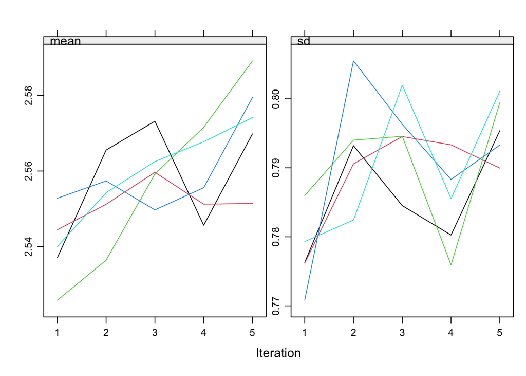

```r
# Start the imputation
MICE.imp.data.regress <- mice(MICE.data, method = method, pred = pred, print = F)
plot(MICE.imp.data.regress, y="log.contact", layout=c(2,1))
```

Again, we can estimate the adjusted odds ratio for influenza vaccination in the imputed datasets:

```r
# Start the analyses
MIversion2 <- with(data = MICE.imp.data.regress, exp = glm(hosp ~ vacc + DM + cvd + pulm + I(log(contact)) + age + sex, family = binomial()))

# Use Rubin's rules
pooledEst <- pool(MIversion2)
```

**Question 1.** Interpret `MICE.imp.data.default` and `MICE.imp.data.regress`. Which method would you prefer for imputing binary and continuous variables?

*For a binary variable, a method that produces a binary outcome is preferable. For instance, logistic regression (‘logreg’) can be used. For a continuous variable, the default is predictive mean matching (‘pmm’), a semi-parametric method which imputes an observed value that has a random value close to the predicted value of the missing observation. Though, for theoretical reasons you may prefer to use the (fully parametric) linear regression (‘norm’). For the variables for which all data are observed, no method is specified (’’). Note that many other methods are possible with the mice package.*

**Question 2 (“Bonus”).** Assess the influence of adjusting the number of multiple imputations and/or the number of iterations. How many imputation and iterations do you think we need?

### Reporting of missing data analysis

In your future work as a data scientist you may often be asked to perform an analysis for a colleague or client. This colleague would need information on how the analysis is performed.  
Select one approach to handling missing data performed during the practicals in the past three weeks and describe it as if you would report back to a colleague (who is interested in fully understanding what you did :)). Use the part of the TRIPOD statement that addresses handling of missing data: https://www.acpjournals.org/doi/10.7326/M14-0698?articleid=2088542